# A generative model for vocabulary estimation

Mike Frank

July 17, 2015

First, connect to the Wordbank database and pull out the English WS and WG data.

```r
wordbank <- connect_to_wordbank()

admins <- get_administration_data() %>%
  filter(language == "English")

items <- get_item_data() %>%
  filter(language == "English", type == "word") %>%
  select(item_id, form, category, lexical_category, item) %>%
  mutate(num_item_id = as.numeric(substr(item_id, 6, nchar(item_id))))

get_form_data <- function(input_language, input_form) {
  form_items <- filter(items, form == input_form)
  get_instrument_data(input_language, input_form,
                      form_items$item_id, iteminfo=form_items) %>%
    mutate(produces = value == "produces",
           understands = value == "understands" | value == "produces") %>%
    select(-value) %>%
    gather(measure, value, produces, understands) %>%
    left_join(select(admins, data_id, age)) %>%
    filter(!is.na(age)) %>%
    mutate(form = input_form)
}

ws <- get_form_data("English", "WS") %>%
  filter(measure == "produces")
```

Now aggregate by item.

```r
items <- ws %>%
  group_by(item, age) %>%
  summarise(produces = mean(value, na.rm=TRUE))

write_csv(items, "ws.csv")
```

Now arrange.

```r
ordered <- items %>%
  group_by() %>%
  arrange(age, desc(produces)) %>%
  group_by(age) %>%
  mutate(index = 1:n())
```

Plot this with a glm sinusoid like in the Mayor & Plunkett (2011) paper.

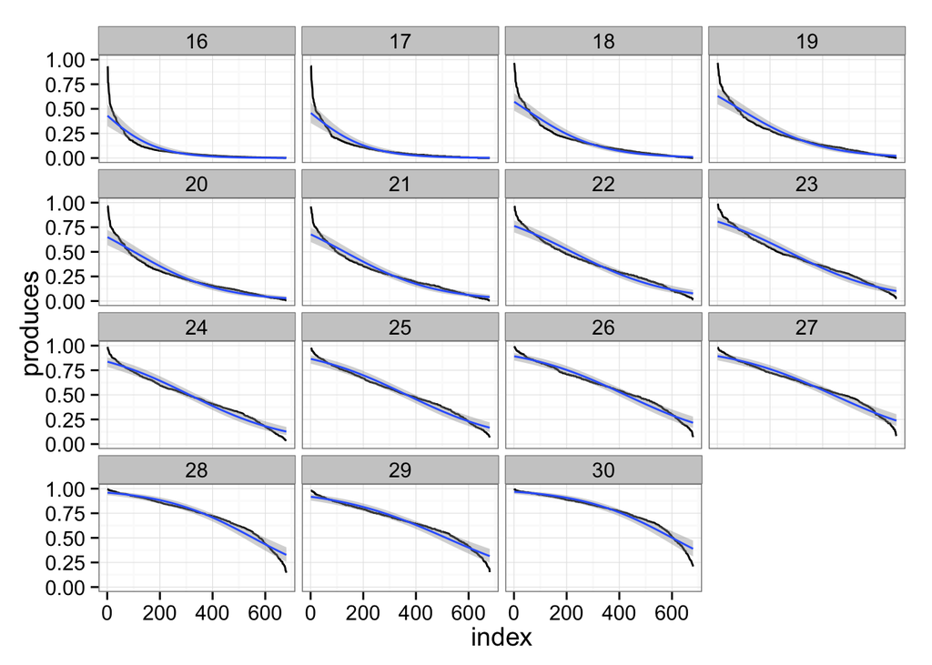

```r
qplot(index, produces, facets= ~age,
      geom = "line",
      data = ordered) +
  ylim(c(0,1)) +
  geom_smooth(method = "glm",
              family = "binomial",
              formula = y ~ x)
```

Try a polynomial fit.

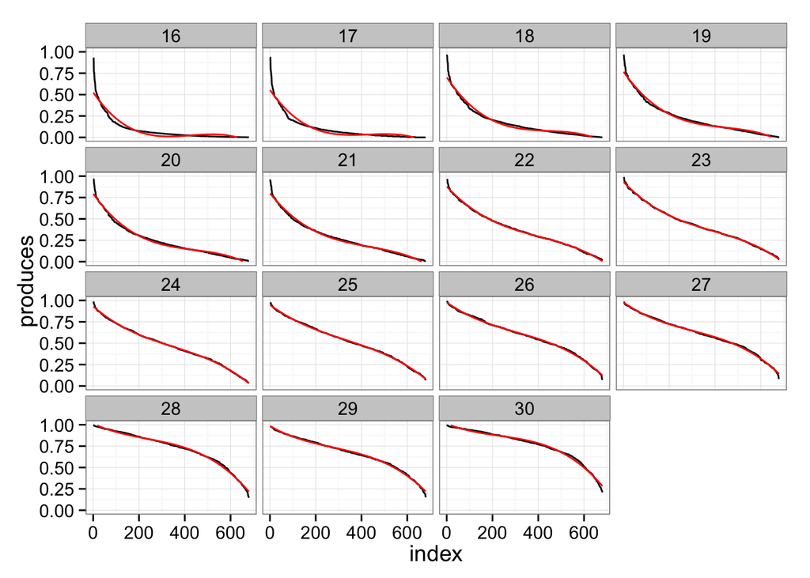

```r
qplot(index, produces, facets= ~age,
      geom = "line",
      data = ordered) +
  ylim(c(0,1)) +
  geom_smooth(method = "lm",
              family = "binomial",
              color = "red",
              formula = y ~ poly(x, 3))
```

Doesn’t work that well for the younger ages, though looks fine later.

Note age interactions in the stats.

```r
mp.glm <- glm(produces ~ index * age, family = "binomial", data = ordered)
summary(mp.glm)
```

```
##
## Call:
## glm(formula = produces ~ index * age, family = "binomial", data = ordered)
##
## Deviance Residuals:
##      Min        1Q    Median        3Q       Max
## -0.51045  -0.09580  -0.01266   0.07168   1.16561
##
## Coefficients:
##               Estimate Std. Error z value Pr(>|z|)
## (Intercept) -4.695e+00  2.839e-01 -16.538  < 2e-16 ***
## index       -7.769e-03  8.480e-04  -9.161  < 2e-16 ***
## age          2.640e-01  1.251e-02  21.100  < 2e-16 ***
## index:age    9.173e-05  3.489e-05   2.629  0.00855 **
## ---
## Signif. codes:  0 '***' 0.001 '**' 0.01 '*' 0.05 '.' 0.1 ' ' 1
##
## (Dispersion parameter for binomial family taken to be 1)
##
##     Null deviance: 4140.24  on 10199  degrees of freedom
## Residual deviance:  175.65  on 10196  degrees of freedom
## AIC: 5984.7
##
## Number of Fisher Scoring iterations: 5
```

### Further thoughts on Mayor & Plunkett model

The Mayor & Plunkett (2011) model has two corrections. The first uses the parametric form of the logistic to fill in low-frequency words that are not on the CDI, the second uses the difference between diary study counts and CDI counts to find a multiplier for higher-frequency words that are omitted.

I think there’s a bit of a conceptual issue here, as these two corrections should essentially be the same thing - there are some words that are not on the CDI, and more of these are the low frequency/hard words. So really, it all is a correction for missing words.

Also - the first correction, which depends on the parametric form of the logistic, is much much smaller than the second. Take a look at this.

Equation 3:

$p(w_i) = 1 - \frac{1}{1 + e^{\frac{-(i-a)}{b}}}$

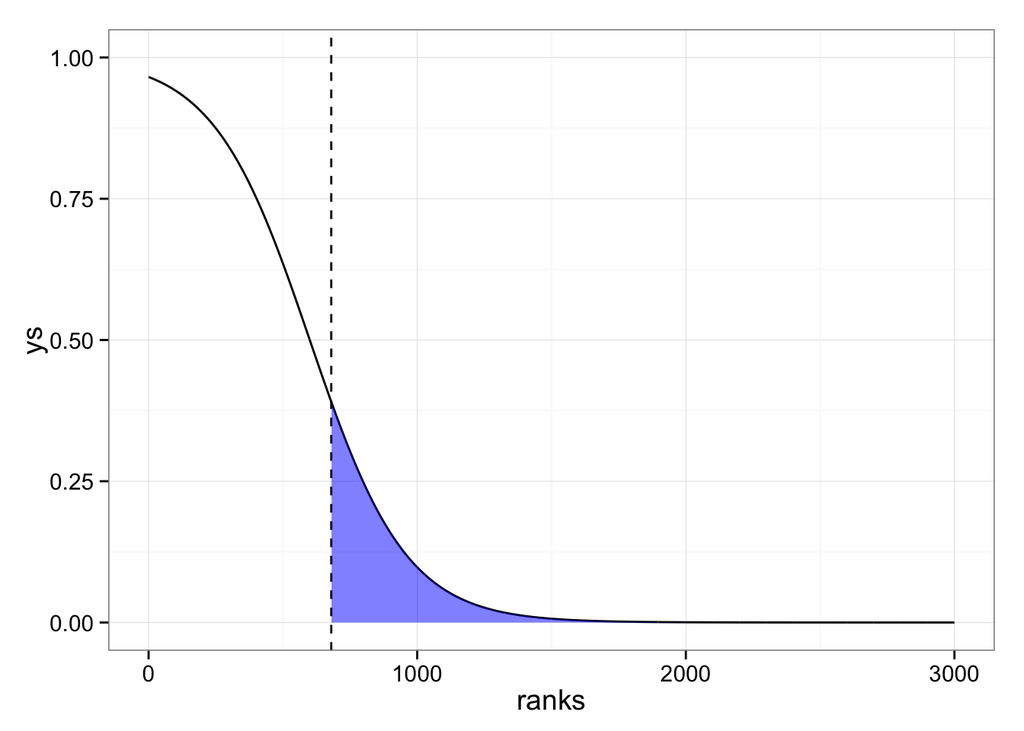

```r
a <- 600 # from figure 6c for a 30mo
b <- 180 # from figure 6c
ranks <- 0:3000
age <- 20
ys <- (1 - (1 / (1 + exp((-(ranks - a ))/b))))

qplot(ranks, ys,
      geom = "line") +
  geom_vline(xintercept = 680, lty = 2) +
  geom_polygon(aes(x = c(ranks[ranks > 680],
                         rev(ranks[ranks > 680])),
                   y = c(ys[ranks > 680],
                         rep(0, length(ranks[ranks > 680])))),
               fill = "blue", alpha = .5) +
  ylim(c(0,1))
```

$V_{corr_1} = b \log (1 + e^(a / b))$

but then adding the second correction is just a multiplier on this:

$V_{corr_2} = \alpha * V_{corr_1}$

Note that (strikingly), M&P2011 never give their value of $\alpha$ in the text. I estimate it below so that I can make an estimate of what correction 2 actually looks like…

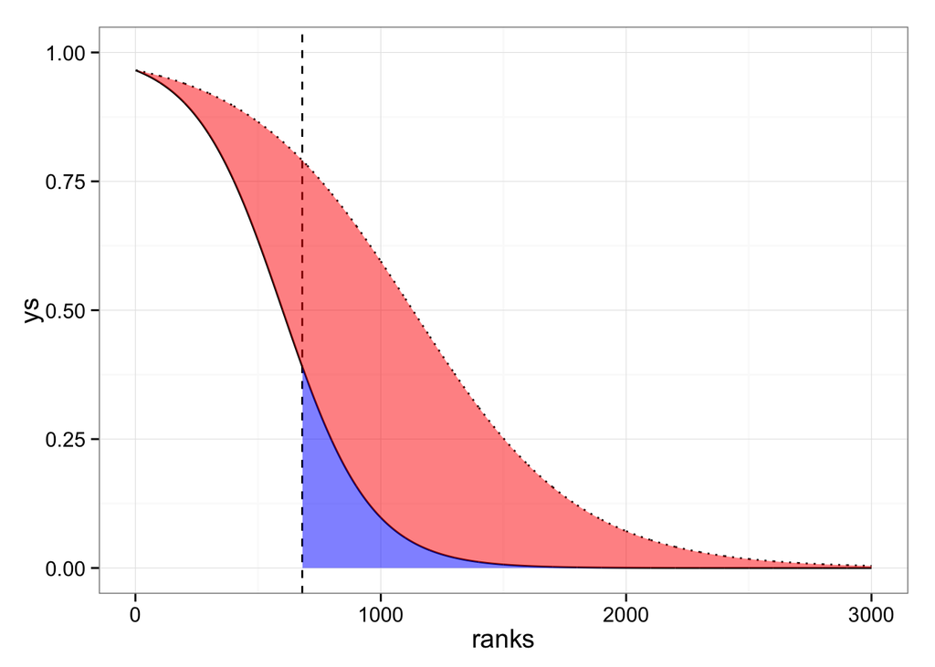

```r
a <- 600
b <- 180
ranks <- 1:3000
age <- 20
ys <- (1 - (1 / (1 + exp((-(ranks - a ))/b))))

area.uncorrected <- sum(ys[1:680])
area.c1 <- b * log(1 + exp(a / b))
area.c2 <- 1142 # from lookup table A1
alpha = area.c2 / area.c1

ys2 <- (1 - (1 / (1 + exp((-(ranks - (a*alpha) ))/(alpha * b)))))
area.corrected <- sum(ys2)

qplot(ranks, ys,
      geom = "line") +
  geom_vline(xintercept = 680, lty = 2) +
  geom_polygon(aes(x = c(ranks[ranks > 680],
                         rev(ranks[ranks > 680])),
                   y = c(ys[ranks > 680],
                         rep(0, length(ranks[ranks > 680])))),
               fill = "blue", alpha = .5) +
  geom_line(aes(y = ys2), lty = 3) +
  geom_polygon(aes(x = c(ranks, rev(ranks)),
                y = c(ys2, rev(ys))),
            fill = "red",
            alpha = .5) +
  ylim(c(0,1))
```

So you can see that the second correction dwarfs the first correction in size, and is really based on a few small diary studies.

In sum, I’m worried about this model for a few reasons:

- The distributional form (logit) is clearly not correct, so using this distributional form for extrapolation may have bad consequences.
- The first and second corrections aren’t conceptually distinct: they both concern missing words. Both have to do with the sampling of words on the CDI from the broader vocabulary.
- The second correction, which does most of the work, is - for reasonable reasons of data etc.- assumed to be a strict multiplier, which makes it do a ton of work at the higher end of vocabulary.

## McMurray Model

This is the normal distribution model from the McMurray (2007) “Defusing the Vocabulary Explosion” paper. Assume kids are $k$ and words $w$. Kids’ abilities are a function of age ($a$). We model production probability $p$.

$k_i \sim \mathcal{N}(\mu_1, \sigma_1) \\ w_j \sim \mathcal{N}(\mu_2, \sigma_2) \\ k_i(a) = k_i * a \\ p(k_i, w_j, a) = k_i(a) > w_j \\$

Try this with arbitrary parameters and make the same plot as above.

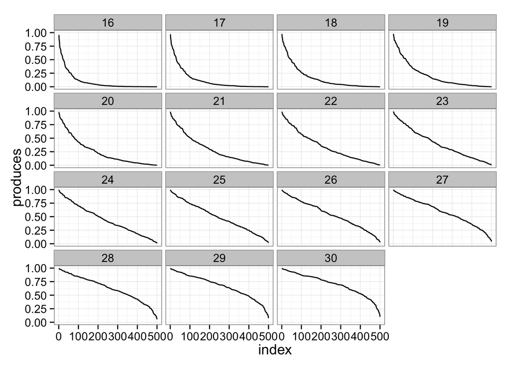

```r
n.words <- 500
n.kids <- 1000

difficulty <- rnorm(n = n.words, m = 100, sd = 20)

ability <- rnorm(n = n.kids, m = 4, sd = 1)
age <- 16:30

sims <- expand.grid(difficulty = difficulty, ability = ability, age = age) %>%
  group_by(ability, age) %>%
  mutate(item = 1:n()) %>%
  group_by() %>%
  mutate(produces = difficulty < ability * age) %>%
  group_by(item, age) %>%
  summarise(produces = mean(produces)) %>%
  group_by() %>%
  arrange(age, desc(produces)) %>%
  group_by(age) %>%
  mutate(index = 1:n())

qplot(index, produces, facets = ~age,
      geom = "line",
      data = sims)
```

Cool - so this looks almost identical in distributional form! Just for kicks, let’s plot these on top of one another. For now I’m just tweaking parameters, though all four ($\mu_1$, $\mu_2$, $\sigma_1$, and $\sigma_2$) matter to the fit.

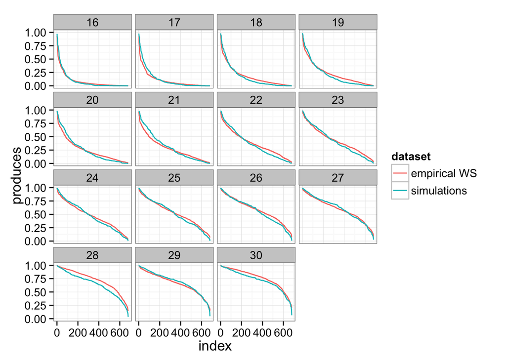

```r
n.words <- 680 # same as on the CDI
n.kids <- 500 # reasonable number, so the curves are smoothish

difficulty <- rnorm(n = n.words, m = 100, sd = 20)

ability <- rnorm(n = n.kids, m = 4, sd = 1)
age <- 16:30

sims <- expand.grid(difficulty = difficulty, ability = ability, age = age) %>%
  group_by(ability, age) %>%
  mutate(item = 1:n()) %>%
  group_by() %>%
  mutate(produces = difficulty < ability * age) %>%
  group_by(item, age) %>%
  summarise(produces = mean(produces)) %>%
  group_by() %>%
  arrange(age, desc(produces)) %>%
  group_by(age) %>%
  mutate(index = 1:n())

sims$dataset <- "simulations"
ordered$dataset <- "empirical WS"
d <- bind_rows(select(sims, index, produces, age, dataset),
               select(ordered, index, produces, age, dataset))

qplot(index, produces, facets = ~age,
      geom = "line",
      col = dataset,
      data = d)
```

## Extending the McMurray Model

So if the McMurray model is more or less the right model of vocabulary growth, how do we use knowledge about its parameters to correct CDI data? Two points here.

First, we have to define a process by which words are excluded and then estimate the parameters of the full model based on the CDI model.

Second, to do this we’re still going to need some facts about total vocabulary to compare to the CDI vocabulary estimates, so we’ll still need a study like Robinson & Mervis (1999).

So let’s consider the McMurray model as the base of our generative model, having the steps:

1. Generate a vocabulary with normally distributed difficulties,
2. Generate a set of kids with normally distributed learning rates, and
3. Generate a set of words to be on an instrument.

Let’s consider a model of selecting words for an instrument where the probability of selecting a word gradually decreases with its difficulty rank. The easiest words (e.g. momma, no, ball) will all be on the list, but only a smaller number of hard words will make it.

$p_{inclusion}(i) \sim \operatorname{Bern} (\frac{1}{i^{\alpha}})$

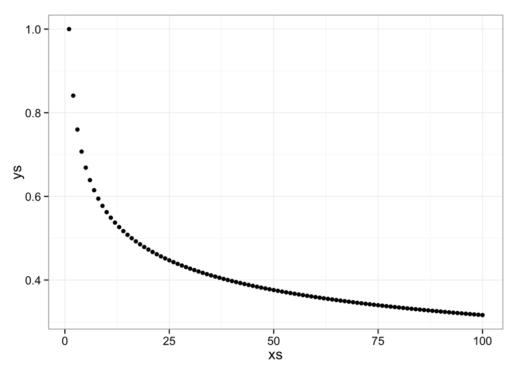

```r
xs <- 1:100
ys <- 1 / xs^(1/4)
qplot(xs, ys)
```

So let’s see what this looks like. We’ll do the same generative process as before but this time with many more words, which we’ll exclude at random.

```r
n.words <- 4000
n.kids <- 100
alpha = .25

difficulty <- rnorm(n = n.words, m = 100, sd = 20)
ability <- rnorm(n = n.kids, m = 4, sd = 1)
age <- 16:30

sims <- expand.grid(difficulty = difficulty, ability = ability, age = age) %>%
  group_by(ability, age) %>%
  mutate(item = 1:n()) %>%
  group_by() %>%
  mutate(produces = difficulty < ability * age) %>%
  group_by(item, age) %>%
  summarise(produces = mean(produces)) %>%
  group_by() %>%
  arrange(age, desc(produces)) %>%
  group_by(age) %>%
  mutate(index = 1:n())
```

Now choose the words to exclude, based on actual ground-truth difficulty.

```r
words.to.include <- expand.grid(difficulty = difficulty) %>%
  mutate(item = 1:n()) %>%
  arrange(difficulty) %>%
  mutate(diff.idx = 1:n()) %>%
  rowwise %>%
  mutate(inc = rbinom(1, size = 1, prob = 1/diff.idx^alpha) == 1) %>%
  filter(inc) %>%
  rowwise %>%
  mutate(sim.idx = sims$index[sims$item == item][1])
```

First visualize this with the words, with red being more included words.

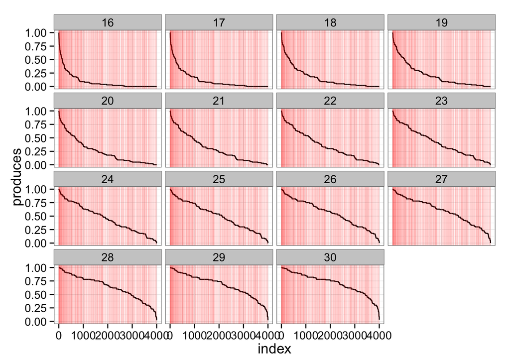

```r
qplot(index, produces, facets = ~age,
      geom = "line",
      data = sims) +
  geom_vline(data = words.to.include,
             aes(xintercept = sim.idx),
             col = "red", alpha = .03)
```

Next show the curves with only those words included.

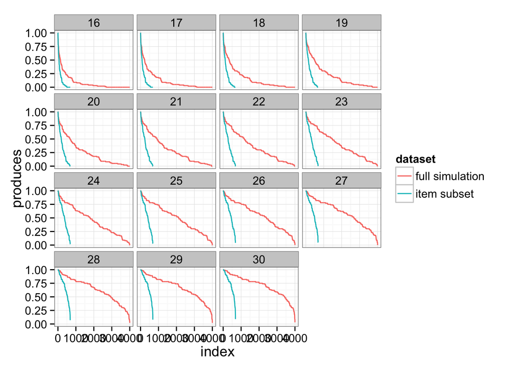

```r
sims.subset <- sims %>%
  filter(item %in% words.to.include$item) %>%
  mutate(index = 1:n())

sims$dataset <- "full simulation"
sims.subset$dataset <- "item subset"

d <- bind_rows(sims, sims.subset)

qplot(index, produces, facets = ~age,
      geom = "line", col = dataset,
      data = d)
```

Now plot the multiplier in this simulation, which we can get based on the area under the curve. (As M&P2011 note, the area under the curve is the expected vocabulary estimate for that measure).

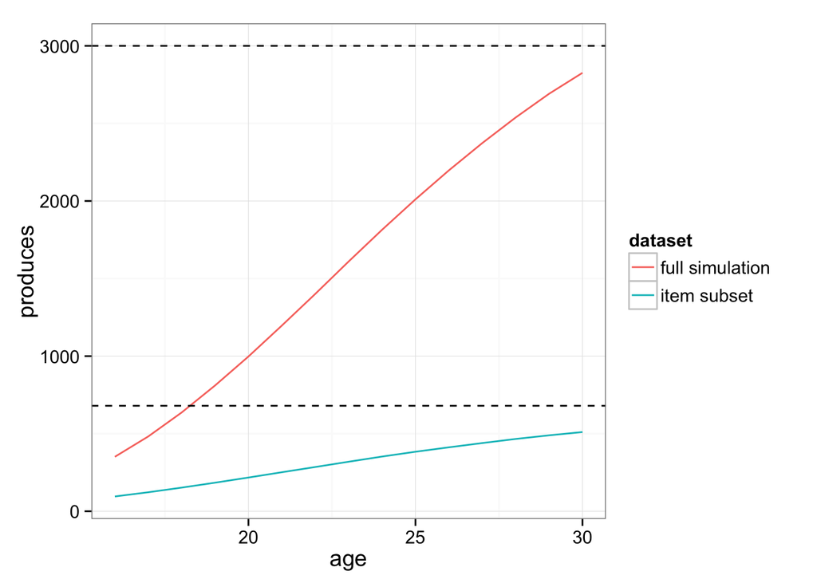

```r
ms <- d %>%
  group_by(age, dataset) %>%
  summarise(produces = sum(produces))

qplot(age, produces, col = dataset,
      geom = "line", data = ms) +
  geom_hline(yintercept = 680, lty = 2) +
  geom_hline(yintercept = 3000, lty = 2)
```